# ONR VR Task Performance

## Overview

```
The following document is intended solely for ID # 73
```

————————————————————————————————————————————————————————————————-I

## Go/No-Go

The Go/No-Go task was the first game you played in VR. This task required you to hit certain shapes that appeared frequently (e.g., a green cube) and to avoid hitting shapes that appeared less frequently or rarely (e.g., red shapes). The shapes that appeared frequently are part of the ‘Go’ trials and the shapes that appeared rarely are part of the ‘No-Go’ trials.

This game essentially measures your **inhibition ability**. Performance for the ‘No-Go’ trials indicate how well you are able to stop yourself from hitting a shape that you are NOT suppose to hit. Over time, this becomes difficult because there are many more ‘Go’ trials than ‘No-Go’ trials, which get you into the habit of hitting shapes. Thus, better performance on the ‘No-Go’ trials can indicate better inhibition ability.

The graph and table below shows how well you did on both ‘Go’ and ‘No-Go’ trials for the different testing days. Performance was calculated by taking the number of correct trials and dividing it by the total number of trials for each respective trial type and then multiplying it by 100. Additionally, the table on the right includes a measure of reaction time. This tells you how quick you were at hitting correct shapes in milliseconds (ms).

————————————————————————————————————————————————————————————————-I

Table 1: Go and No-Go trial performance and reaction times between testing conditions.

| Day | Trial Type | Performance | Reaction Time (ms) |
| --- | --- | --- | --- |
| Rest | Go | 96.8% | 768 |
| Rest | No-Go | 96.6% | —- |
| Exercise | Go | 93% | 797 |
| Exercise | No-Go | 98.8% | —- |

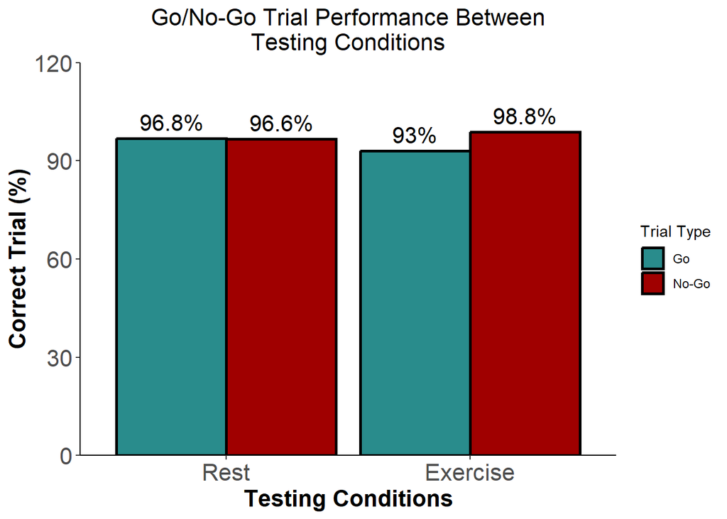

————————————————————————————————————————————————————————————————-I

## NBack

The Nback was the second game you played in VR and is considered to be harder than the first one. Our version of this task required you to hit a shape if it matched a shape that you saw two trials back. This type of task measures your **working memory**. This is your ability to hold and manipulate information in your mind. So it is similar to memory, but contains extra steps which makes it harder. The shapes that matched the ones that were presented two trials back are called ‘Targets’ and all the other shapes are called ‘Non-Targets.’ Essentially, the better the performance on the ‘Target’ trials, the better your working memory performance was.

The graph and table below shows how well you did on both ‘Target’ and ‘Non-Target’ trials for the different testing days. However, the ‘Target’ trial performance is much more informative for working memory than the ‘Non-Target’ trials. Just like for the Go/No-Go, performance was calculated by taking the number of correct trials and dividing it by the total number of trials for each respective trial type and then multiplying it by 100. Additionally, the table on the right includes a measure of reaction time. This tells you how quick you were at hitting correct shapes that were supposed to be hit in milliseconds (ms). ————————————————————————————————————————————————————————————————-I

Table 2: Target and Non-Targert trial performance and reaction times between testing conditions.

| Day | Trial Type | Performance | Reaction Time (ms) |
| --- | --- | --- | --- |
| Rest | Non-Target | 98% | —- |
| Rest | Target | 64.5% | 724 |
| Exercise | Non-Target | 98.5% | —- |
| Exercise | Target | 62.5% | 783 |

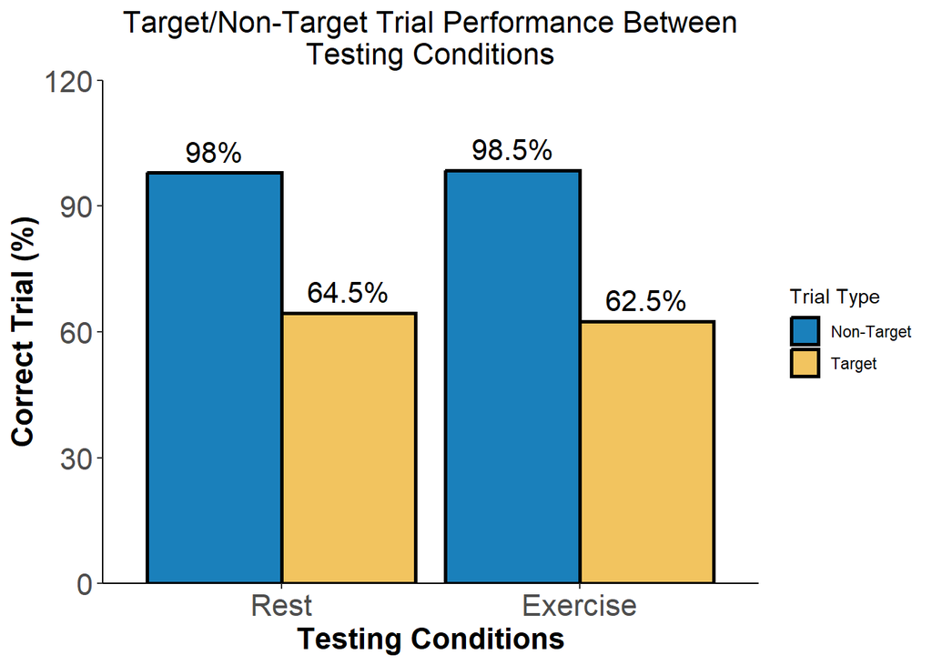

————————————————————————————————————————————————————————————————-I